# MKarimi-Project03

## Data Mining

### درس داده کاوی

#### **تمرین های درس داده کاوی، الگوریتم ها و کاربرد ها - دکتر مربی** دانشجو: مصطفی کریمی

#### **#============== پروژه سوم و چهارم ==============#**

#### یک فایل شامل متغیر کمی و متغیر اسمی با حجم بیش از 200 داده که لااقل یکی از متغیر های کمی شامل گمشده نیز باشد انتخاب کرده.

### Description

About data set This database contains 76 attributes, but all published experiments refer to using a subset of 14 of them. In particular, the Cleveland database is the only one that has been used by ML researchers to this date.The "target" field refers to the presence of heart disease in the patient. It is integer valued 0 = no/less chance of heart attack and 1 = more chance of heart attack

Attribute Information

> - 1) age
> - 2) sex
> - 3) chest pain type (4 values)
> - 4) resting blood pressure
> - 5) serum cholestoral in mg/dl
> - 6) fasting blood sugar > 120 mg/dl
> - 7) resting electrocardiographic results (values 0,1,2)
> - 8) maximum heart rate achieved
> - 9) exercise induced angina
> - 10) oldpeak = ST depression induced by exercise relative to rest
> - 11) the slope of the peak exercise ST segment
> - 12) number of major vessels (0-3) colored by flourosopy
> - 13) thal: 0 = normal; 1 = fixed defect; 2 = reversable defect
> - 14) target: 0= less chance of heart attack 1= more chance of heart attack

Reference: [Kaggle](https://www.kaggle.com/nareshbhat/health-care-data-set-on-heart-attack-possibility)

```python
import pandas as pd

heart = pd.read_csv("heart.csv")

print(heart[1:5])
heart.info()
```

```
   age  sex  cp  trestbps  chol  fbs  restecg  thalach  exang  oldpeak  slope  \
1   37    1   2       130   250    0        1      187      0      3.5      0
2   41    0   1       130   204    0        0      172      0      1.4      2
3   56    1   1       120   236    0        1      178      0      0.8      2
4   57    0   0       120   354    0        1      163      1      0.6      2

   ca  thal  target   sex_n             thal_n                     target_n  \
1   0     2       1    male  reversable defect  more chance of heart attack
2   0     2       1  female  reversable defect  more chance of heart attack
3   0     2       1    male  reversable defect  more chance of heart attack
4   0     2       1  female  reversable defect  more chance of heart attack

   chol_n compare
1     250
2     204
```

[output cut: 28 more lines]

#### فراخوانی داده ها و انتقال آن ها در ماتریس های مشخص

```python
heart_age = [heart['age'][i] for i in range(303)]
heart_sex = [heart['sex_n'][i] for i in range(303)]
heart_chol = [heart['chol'][i] for i in range(303)]


print("\t Age of Person: \n{}\n\n\t Sex of Person:\n{}\n\n\t Serum Cholestoral:\n{}".format(heart_age, heart_sex, heart_chol))
```

```
	 Age of Person:
[63, 37, 41, 56, 57, 57, 56, 44, 52, 57, 54, 48, 49, 64, 58, 50, 58, 66, 43, 69, 59, 44, 42, 61, 40, 71, 59, 51, 65, 53, 41, 65, 44, 54, 51, 46, 54, 54, 65, 65, 51, 48, 45, 53, 39, 52, 44, 47, 53, 53, 51, 66, 62, 44, 63, 52, 48, 45, 34, 57, 71, 54, 52, 41, 58, 35, 51, 45, 44, 62, 54, 51, 29, 51, 43,…

	 Sex of Person:
['male', 'male', 'female', 'male', 'female', 'male', 'female', 'male', 'male', 'male', 'male', 'female', 'male', 'male', 'female', 'female', 'female', 'female', 'male', 'female', 'male', 'male', 'male', 'male', 'male', 'female', 'male', 'male', 'female', 'male', 'female', 'male', 'male', 'male', 'ma…

	 Serum Cholestoral:
[233, 250, 204, 236, 354, 192, 294, 263, 199, 168, 239, 275, 266, 211, 283, 219, 340, 226, 247, 239, 234, 233, 226, 243, 199, 302, 212, 175, 417, 197, 198, 177, 219, 273, 213, 177, 304, 232, 269, 360, 308, 245, 208, 264, 321, 325, 235, 257, 216, 234, 256, 302, 231, 141, 252, 201, 222, 260, 182, 303,…
```

```python
import random as rd

r = [rd.randint(0, 302) for i in range(3)]

print(r,"\n")

[print("Age Person {} is {}, gender is {} and cholestoral is {} \n".format(r[i], heart_age[r[i]], heart_sex[r[i]], heart_chol[r[i]])) for i in range(3)]
```

```
[125, 145, 30]

Age Person 125 is 34, gender is female and cholestoral is 210

Age Person 145 is 70, gender is male and cholestoral is 245

Age Person 30 is 41, gender is female and cholestoral is 198
```

```
[None, None, None]
```

#### داده های گمشده در متغیر های کمی را جایگذاری کنید و در متغیر های جدید ذخیره کنید.

#### بررسی برای سن افراد

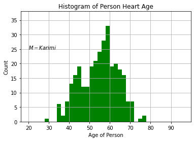

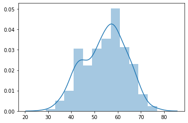

```python
import matplotlib.pyplot as plt
import numpy as np

bins = np.arange(20, max(heart_age)+20, 2)

a = plt.hist(heart_age, bins = bins, facecolor='g')

plt.xlabel("Age of Person")
plt.ylabel("Count")
plt.title("Histogram of Person Heart Age")
plt.text(20, 25, r'$M-Karimi$')
plt.ylim(0, 38)
plt.grid(True)
plt.show()

import seaborn as sb

sb.distplot(heart_age);
```

#### بررسی برای میزان کلسترول

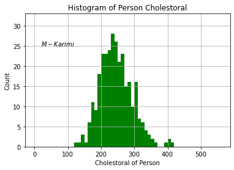

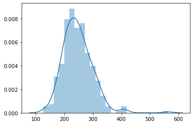

```python
import matplotlib.pyplot as plt
import numpy as np
import seaborn as sb

bins = np.arange(0, max(heart_chol)+1, 10)

a = plt.hist(heart_chol, bins = bins, facecolor='g')



plt.xlabel("Cholestoral of Person")
plt.ylabel("Count")
plt.title("Histogram of Person Cholestoral")
plt.text(20, 25, r'$M-Karimi$')
plt.ylim(0, 33)
plt.grid(True)
plt.show()

sb.distplot(heart_chol);
```

#### پراکندی داده ها یا Scatterplots

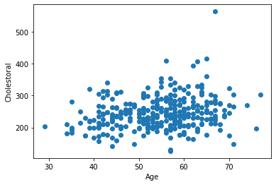

```python
plt.scatter(data = heart, x = 'age', y = 'chol');

plt.xlabel("Age")
plt.ylabel("Cholestoral");
```

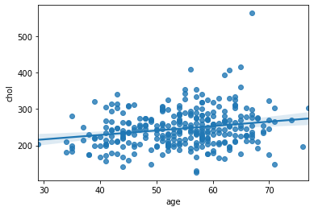

```python
sb.regplot(data = heart, x = 'age', y = 'chol');
```

#### ایجاد دامنه پراکندگی و جایگزینی آن با میانه کلسترول

```python
import statistics as stc

h_median = stc.median(heart_chol)
print("Median is: {}".format(h_median))

h_Qua = stc.quantiles(heart_chol)
h_IQR = h_Qua[2] - h_Qua[0]

print("Quantile: {}".format(h_Qua))

h_DisIQR = h_IQR * 1.5
print("Distance of IQR: {}".format(h_DisIQR))

h_IQLow = h_Qua[0] - h_DisIQR
h_IQHig = h_Qua[2] + h_DisIQR

print("Low is [* {} *] and High is [* {} *]".format(h_IQLow, h_IQHig))
```

```
Median is: 240
Quantile: [211.0, 240.0, 275.0]
Distance of IQR: 96.0
Low is [* 115.0 *] and High is [* 371.0 *]
```

#### حذف نوییز ها از داده های کلسترول و جایگزینی آن ها با میانه

```python
import statistics as stc

h_median = stc.median(heart_chol)

heart_newChol = [0]*303
print(heart_newChol,"\n")

for i in range(len(heart_chol)):
    if heart_chol[i] > h_IQLow and heart_chol[i] < h_IQHig:
        heart_newChol[i] = heart_chol[i]
    else:
        heart_newChol[i] = h_median

print(heart_newChol)
```

```
[0, 0, 0, 0, 0, 0, 0, 0, 0, 0, 0, 0, 0, 0, 0, 0, 0, 0, 0, 0, 0, 0, 0, 0, 0, 0, 0, 0, 0, 0, 0, 0, 0, 0, 0, 0, 0, 0, 0, 0, 0, 0, 0, 0, 0, 0, 0, 0, 0, 0, 0, 0, 0, 0, 0, 0, 0, 0, 0, 0, 0, 0, 0, 0, 0, 0, 0, 0, 0, 0, 0, 0, 0, 0, 0, 0, 0, 0, 0, 0, 0, 0, 0, 0, 0, 0, 0, 0, 0, 0, 0, 0, 0, 0, 0, 0, 0, 0, 0, 0,…

[233, 250, 204, 236, 354, 192, 294, 263, 199, 168, 239, 275, 266, 211, 283, 219, 340, 226, 247, 239, 234, 233, 226, 243, 199, 302, 212, 175, 240, 197, 198, 177, 219, 273, 213, 177, 304, 232, 269, 360, 308, 245, 208, 264, 321, 325, 235, 257, 216, 234, 256, 302, 231, 141, 252, 201, 222, 260, 182, 303,…
```

```
[233, 250, 204, 236, 354, 192, 294, 263, 199, 168, 239, 275, 266, 211, 283, 219, 340, 226, 247, 239, 234, 233, 226, 243, 199, 302, 212, 175, 240, 197, 198, 177, 219, 273, 213, 177, 304, 232, 269, 360, 308, 245, 208, 264, 321, 325, 235, 257, 216, 234, 256, 302, 231, 141, 252, 201, 222, 260, 182, 303,…
```

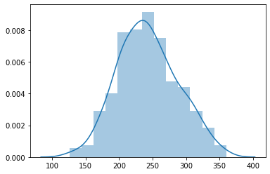

```python
import seaborn as sb



print(heart_newChol)
sb.distplot(heart_newChol);
```

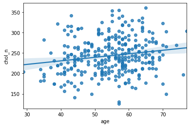

```python
sb.regplot(data = heart, x = 'age', y = 'chol_n');
```

#### محاسبه رگرسیون بعد از تمیز کاری

$$ y = w_{1}x_{1} + w_{2}x_{2} + w_{3}x_{3} + b$$$$ \left\{\begin{matrix} x_{1} = age\\ x_{2} = cholestoral\\ x_{3} = fasting - blood - sugar \end{matrix}\right. $$$$ y = target $$

```python
import numpy as np
from sklearn.linear_model import LinearRegression

x = []
for i in range(len(heart_newChol)):
    x_m = []
    x_m.append(heart['age'][i])
    x_m.append(heart['chol_n'][i])
    x_m.append(heart['fbs'][i])
    x.append(x_m)

y = []
for j in range(len(heart_newChol)):
    y.append(heart['target'][j])

x, y = np.array(x), np.array(y)


print("\n\t Way 1: X = \n\n{}\n\n\t Way 2: Y = \n\n{}".format(x, y))
```

```
	 Way 1: X =

[[ 63 233   1]
 [ 37 250   0]
 [ 41 204   0]
 [ 56 236   0]
 [ 57 354   0]
 [ 57 192   0]
 [ 56 294   0]
 [ 44 263   0]
 [ 52 199   1]
 [ 57 168   0]
 [ 54 239   0]
 [ 48 275   0]
 [ 49 266   0]
 [ 64 211   0]
 [ 58 283   1]
 [ 50 219   0]
 [ 58 340   0]
 [ 66 226   0]
 [ 43 247   0]
 [ 69 239   0]
 [ 59 234   0]
 [ 44 233   0]
 [ 42 226   0]
 [ 61 243   1]
 [ 40 199   0]
 [ 71 302   0]
 [ 59 212   1]
 [ 51 175   0]
 [ 65 240   1]
 [ 53 197   1]
 [ 41 198   0]
 [ 65 177   0]
 [ 44 219   0]
 [ 54 273   0]
 [ 51 213   0]
 [ 46 177   0]
 [ 54 304   1]
 [ 54 232   0]
```

[output cut: 262 more lines]

```
 [ 68 193   1]
 [ 57 131   0]
 [ 57 236   0]]

	 Way 2: Y =

[1 1 1 1 1 1 1 1 1 1 1 1 1 1 1 1 1 1 1 1 1 1 1 1 1 1 1 1 1 1 1 1 1 1 1 1 1
 1 1 1 1 1 1 1 1 1 1 1 1 1 1 1 1 1 1 1 1 1 1 1 1 1 1 1 1 1 1 1 1 1 1 1 1 1
 1 1 1 1 1 1 1 1 1 1 1 1 1 1 1 1 1 1 1 1 1 1 1 1 1 1 1 1 1 1 1 1 1 1 1 1 1
 1 1 1 1 1 1 1 1 1 1 1 1 1 1 1 1 1 1 1 1 1 1 1 1 1 1 1 1 1 1 1 1 1 1 1 1 1
 1 1 1 1 1 1 1 1 1 1 1 1 1 1 1 1 1 0 0 0 0 0 0 0 0 0 0 0 0 0 0 0 0 0 0 0 0
 0 0 0 0 0 0 0 0 0 0 0 0 0 0 0 0 0 0 0 0 0 0 0 0 0 0 0 0 0 0 0 0 0 0 0 0 0
 0 0 0 0 0 0 0 0 0 0 0 0 0 0 0 0 0 0 0 0 0 0 0 0 0 0 0 0 0 0 0 0 0 0 0 0 0
 0 0 0 0 0 0 0 0 0 0 0 0 0 0 0 0 0 0 0 0 0 0 0 0 0 0 0 0 0 0 0 0 0 0 0 0 0
 0 0 0 0 0 0 0]
```

```python
print(type(x), np.shape(x))
```

```
<class 'numpy.ndarray'> (303, 3)
```

#### حل مدل با رگرسیون

```python
model = LinearRegression().fit(x, y)
```

#### نمایش خروجی

```python
r_sq = model.score(x, y)
intercept = model.intercept_
slop = model.coef_

print(" Coefficient of Determination:  {} \n Intercept:\t\t\t{} \n Slop:\t\t\t\t{}".format(r_sq, intercept, slop))
```

```
 Coefficient of Determination:  0.05684454144214579
 Intercept:			1.3898493295980205
 Slop:				[-0.01161194 -0.00087923 -0.00234402]
```

#### پیش بینی

```python
a = ['Age', 'Cholesteral', 'Fasting Blood Sugar']


x_new = [int(input("Input {}:\n".format(a[i]))) for i in range(3)]

# x_n = np.array(x_new)

# y_new = model.predict(x_new)

# print(y_new)

y_n = [x_new[j]*slop[j] for j in range(3)]
y_pred = (sum(y_n)*r_sq) + intercept

print("Prediction: {}".format(y_pred))
```

```
Input Age:
55
Input Cholesteral:
190
Input Fasting Blood Sugar:
0
Prediction: 1.3440490430711238
```

#### محاسبه آزمون کای دو

#### آزمون برای میزان کلسترول

```python
print(heart['chol_n'])
```

```
0      233
1      250
2      204
3      236
4      354
      ...
298    241
299    264
300    193
301    131
302    236
Name: chol_n, Length: 303, dtype: int64
```

```python
Mn_h = min(heart['chol_n'])
Mx_h = max(heart['chol_n'])

print("Min: ",Mn_h, "| Max: ", Mx_h)

Domain = (Mx_h - Mn_h) / 5

print("Range: ", Domain)

D_ch = [0] * 6
D_ch[0] = Mn_h
for i in range(1, 6):
    D_ch[i] += D_ch[i-1] + Domain

print(D_ch)
```

```
Min:  126 | Max:  360
Range:  46.8
[126, 172.8, 219.60000000000002, 266.40000000000003, 313.20000000000005, 360.00000000000006]
```

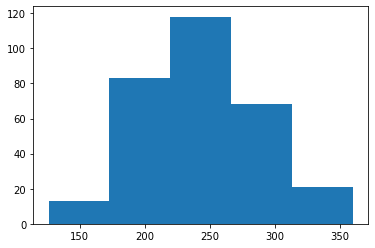

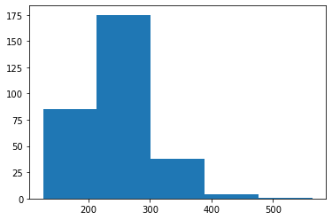

```
Skewness befor deleting: 1.1377326187082244
Skewness after deleting: 0.18382714964513103
```

```python
import matplotlib.pyplot as plt
from scipy.stats import skew

plt.hist(heart_newChol, bins = 5);
plt.show()

plt.hist(heart['chol'], bins = 5);
plt.show()

print("Skewness befor deleting: {}".format(skew(heart['chol'])))
print("Skewness after deleting: {}".format(skew(heart_newChol)))
```

```python
groups = pd.cut(heart_newChol, bins = D_ch)

O = groups.value_counts()

print(O)

print(O[0])
```

```
(126.0, 172.8]     12
(172.8, 219.6]     83
(219.6, 266.4]    118
(266.4, 313.2]     68
(313.2, 360.0]     21
dtype: int64
12
```

```python
err = [O[i]/sum(O) for i in range(5)]

print(err)
```

```
[0.039735099337748346, 0.27483443708609273, 0.39072847682119205, 0.2251655629139073, 0.0695364238410596]
```

#### مقدار 3 سیگما در توزیع نرمال

$$ 1\sigma = 64.2 $$ $$ 2\sigma = 13.6 * 2 $$ $$ 3\sigma = 2.1 * 2 $$

```python
sig1 = 0.642
sig2 = 0.136
sig3 = 0.021
n = 303

E = [n*sig3, n*sig2, n*sig1, n*sig2, n*sig3]
print(E)
```

```
[6.363, 41.208000000000006, 194.526, 41.208000000000006, 6.363]
```

```python
from scipy.stats import chi2


X_lis = [((O[i]-E[i])**2)/E[i] for i in range(5)]
X_2 = sum(X_lis)

X_24 = chi2.ppf(0.95, df=4)

CM = "فرض صفر رد می شود"

if X_2 > X_24:
    print("Result: \n\t Chi List: {} \n\t Chi 2 : {} \n\t Chi2 df = 4: {}".format(X_lis, X_2, X_24))
    print("\n\t\t\t{0} {1} {0}".format(3*"*", CM))

else:
    print("Result: \n\t Chi List: {} \n\t Chi 2 : {} \n\t Chi2 df = 4: {}".format(X_lis, X_2, X_24))
    print("\n\t{0} {1} {0}".format(3*"*", "فرض صفر رد نمی شود"))
```

```
Result:
	 Chi List: [4.99383451202263, 42.38427645117451, 30.105120528875325, 17.4192211221122, 33.669930693069304]
	 Chi 2 : 128.57238330725397
	 Chi2 df = 4: 9.487729036781154

			*** فرض صفر رد می شود ***
```